## Curso de R no IPÊ

### Script do dia 3.2: Regressão

*Marcos V. C. Vital e participantes da turma de 2014*

Para mais material, acesse http://marcosvital.wordpress.com/

Este documento é a segunda parte do terceiro de uma série que nasceu durante as atividades do “Curso de introdução ao uso do software R e suas aplicações estatísticas nas ciências biológicas”, realizado no IPÊ em dezembro de 2014.

Nesta parte do guia nós vamos realizar uma análise de regressão linear simples, e fuçar um bocado em possibilidades de como lidar com seus resultados.

Como sempre, todo o documento foi criado utilizando o software R, o programa RStudio e a linguagem Markdown. Para saber mais, acesse:

http://www.r-project.org/

http://www.rstudio.com

http://rmarkdown.rstudio.com/

**Antes de começar, carregue os dados necessários:**

```r
setwd("C:/R/Curso IPÊ")
dados<-read.table("latitude.txt", h=T)
attach(dados)

summary(dados)
```

```
##     Latitude        Riqueza
##  Min.   : 5.00   Min.   : 3.000
##  1st Qu.:17.00   1st Qu.: 4.000
##  Median :29.00   Median : 6.000
##  Mean   :29.97   Mean   : 8.655
##  3rd Qu.:44.00   3rd Qu.:11.000
##  Max.   :60.00   Max.   :32.000
```

#### A regressão linear simples

Vamos bem direto ao ponto, realizar a análise e fazer o gráfico, e deixaremos os pressupostos para depois. Não é o protocolo normal da coisa, mas vamos fazer isso apenas para gerarmos um exemplo rápido.

Lá vai:

```r
resultado<-lm(Riqueza~Latitude)

summary(resultado)
```

```
##
## Call:
## lm(formula = Riqueza ~ Latitude)
##
## Residuals:
##    Min     1Q Median     3Q    Max
## -4.269 -2.655 -1.587  2.595 15.117
##
## Coefficients:
##             Estimate Std. Error t value Pr(>|t|)
## (Intercept) 18.53090    1.59108  11.647 4.90e-12 ***
## Latitude    -0.32957    0.04665  -7.065 1.35e-07 ***
## ---
## Signif. codes:  0 '***' 0.001 '**' 0.01 '*' 0.05 '.' 0.1 ' ' 1
##
## Residual standard error: 4.093 on 27 degrees of freedom
## Multiple R-squared:  0.649,  Adjusted R-squared:  0.636
## F-statistic: 49.92 on 1 and 27 DF,  p-value: 1.35e-07
```

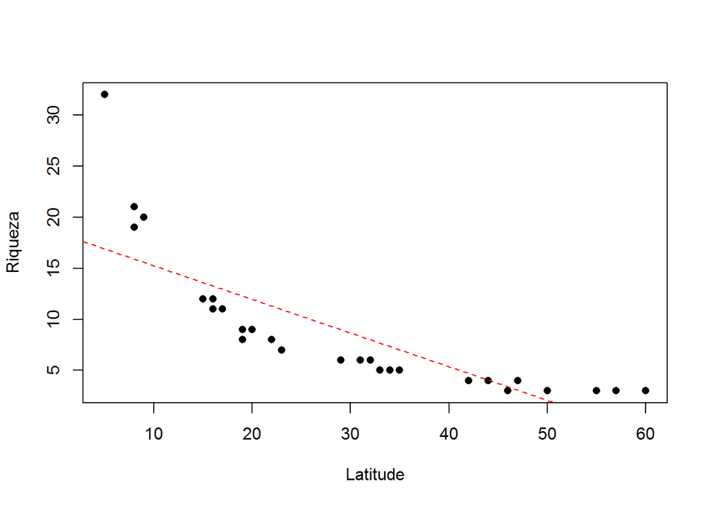

```r
plot(Riqueza~Latitude, pch=16)
abline(resultado, col="red", lty=2)
```

Fica bem claro que a relação não é linear, não é?

**Então vamos aos pressupostos!**

Beleza, estamos falando de um modelo linear, então a história é mais ou menos a mesma. A diferença daqui para a anova é que não temos grupos para se calcular variâncias, então vamos avaliar um pressuposto da homocedasticidade dos resíduos (que é bem parecido com o de homogeneidade de variâncias).

Vamos começar por este pressuposto novo, então, que devemos avaliar por um diagnóstico visual:

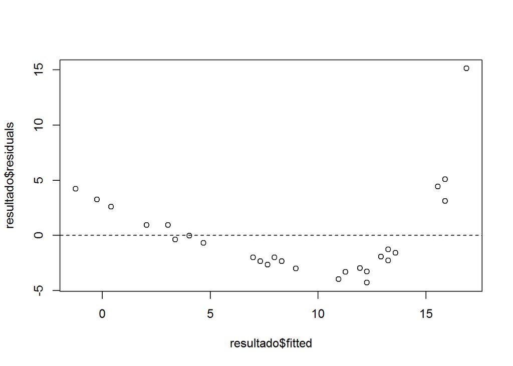

```r
plot(resultado$fitted, resultado$residuals,
abline(h=0,lty=2))
```

Ficou horrendo! :P

Os resíduos com certeza não são homocedásticos.

Vamos conferir a normalidade dos resíduos também:

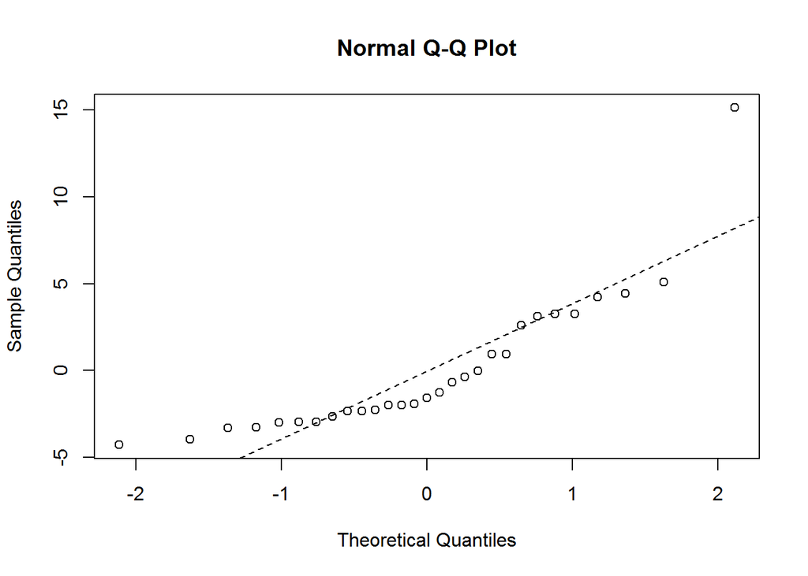

```r
qqnorm(resultado$residuals)
qqline(resultado$residuals, lty=2)
```

Também não está nada bom.

O nosso modelo, então, viola os pressupostos. E agora, o que fazer?

#### Um teste não paramétrico?

Podemos calcular uma simples correlação de spearman, que é uma métrica não paramétrica de correlação, baseada em ranks. Ela não é la muito informativa, mas pelo menos nos dá um resultado estatisticamente confiável:

```r
cor(Latitude, Riqueza, method="spearman")
```

```
## [1] -0.9871166
```

```r
#Fazendo o teste de significância da correlação:

cor.test(Latitude, Riqueza, method="spearman")
```

```
##
##  Spearman's rank correlation rho
##
## data:  Latitude and Riqueza
## S = 8067.693, p-value < 2.2e-16
## alternative hypothesis: true rho is not equal to 0
## sample estimates:
##        rho
## -0.9871166
```

O resultado indicou o que podemos ver no gráfico: há uma forte correlação negativa entre as duas variáveis.

Mas com este método não podemos avançar muito… Então vamos brincar um pouco com algumas possibilidades, ok? Boa parte dos procedimentos a seguir serão feitos mais para ilustrar funcionaliades do R do que para indicar como os dados deveriam ser analisados de verdade. Então não leve a coisa à sério demais, e use o exemplo para explorar as capacidades do R.

#### Tentativa 1: vamos tentar tirar um ponto com carinha de outlier:

Vamos identificar os pontos no nosso gráfico:

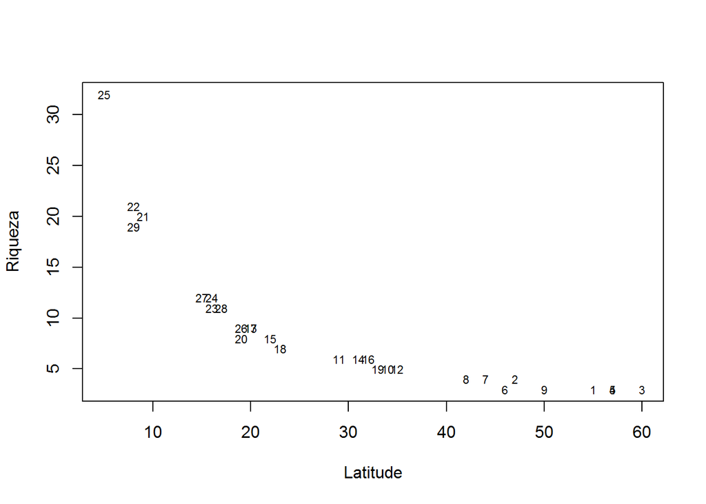

```r
plot(Riqueza~Latitude, pch=16, type="n")
text(x=Latitude, y=Riqueza, cex=0.7)
```

É, aquele ponto 25 está meio fora dos padrões, não é?

Digamos, então, que você decida que ele pode ser retirado da análise. Imagine, por exemplo, que você descobriu que aquele na verdade é um ponto totalmente atípico, com uma riqueza de espécies muito mais alta do que outros na mesma latitude. Podemos removê-lo da análise e ver se as coisas melhoram no nosso modelo.

Será? Vamos ver:

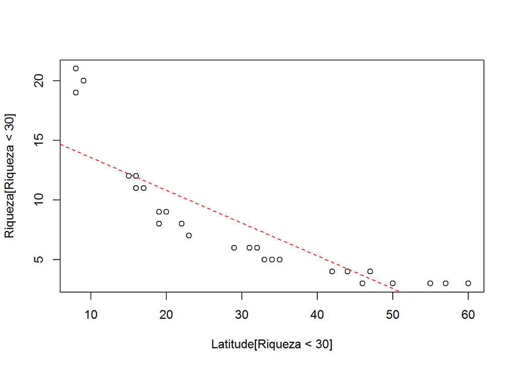

```r
resultado2<-lm(Riqueza[Riqueza<30]~Latitude[Riqueza<30])
plot(Riqueza[Riqueza<30]~Latitude[Riqueza<30])
abline(resultado2, lty=2, col="red")
```

A carinha do modelo em si ficou melhor. Mas será que isso ajudou com os pressupostos? Vamos ver:

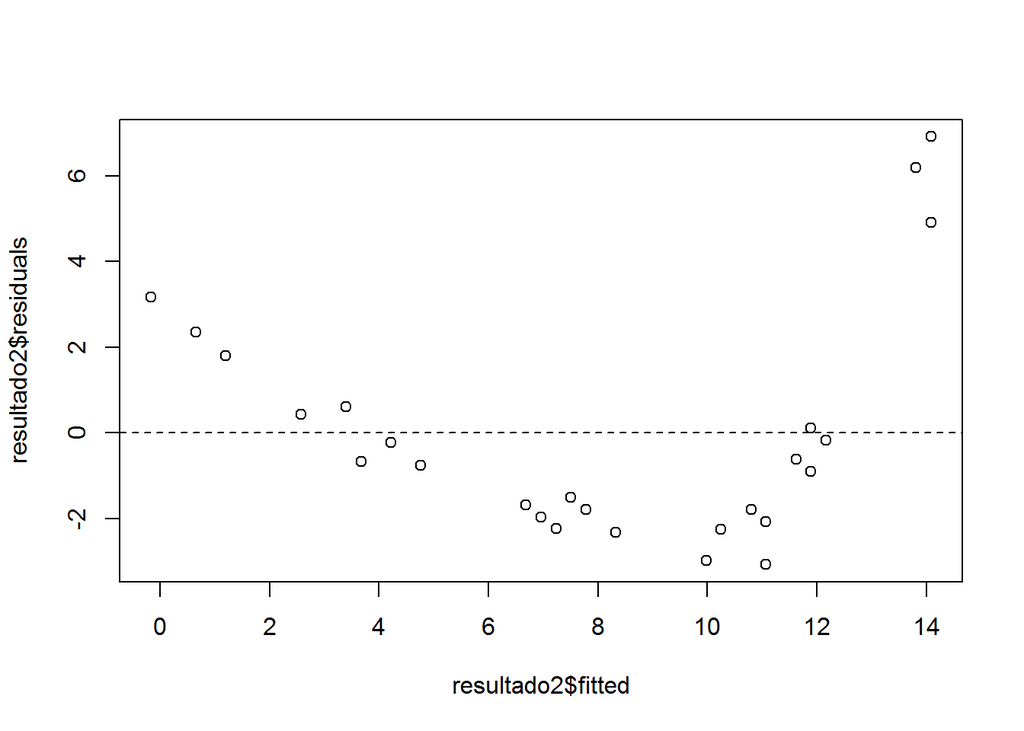

```r
plot(resultado2$fitted, resultado2$residuals,
abline(h=0,lty=2))
```

Nope. Continua bem ruinzinho.

#### Tentativa 2: transformação dos dados:

Uma outra possibilidade é transformar os dados e ver no que dá. Vamos tentar uma transformação por logarítmo:

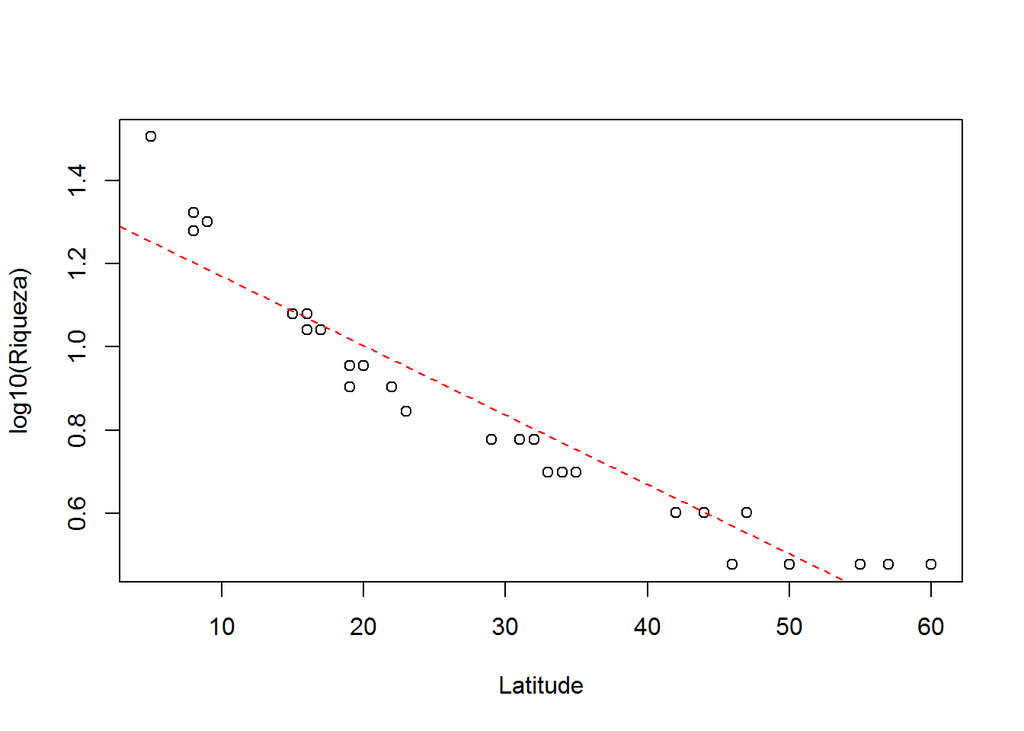

```r
resultado3<-lm(log10(Riqueza)~Latitude)
plot(log10(Riqueza)~Latitude)
abline(resultado3, lty=2, col="red")
```

Hum, a carinha do modelo melhorou bastante! Mas vamos ver como estão os nosso amigos resíduos:

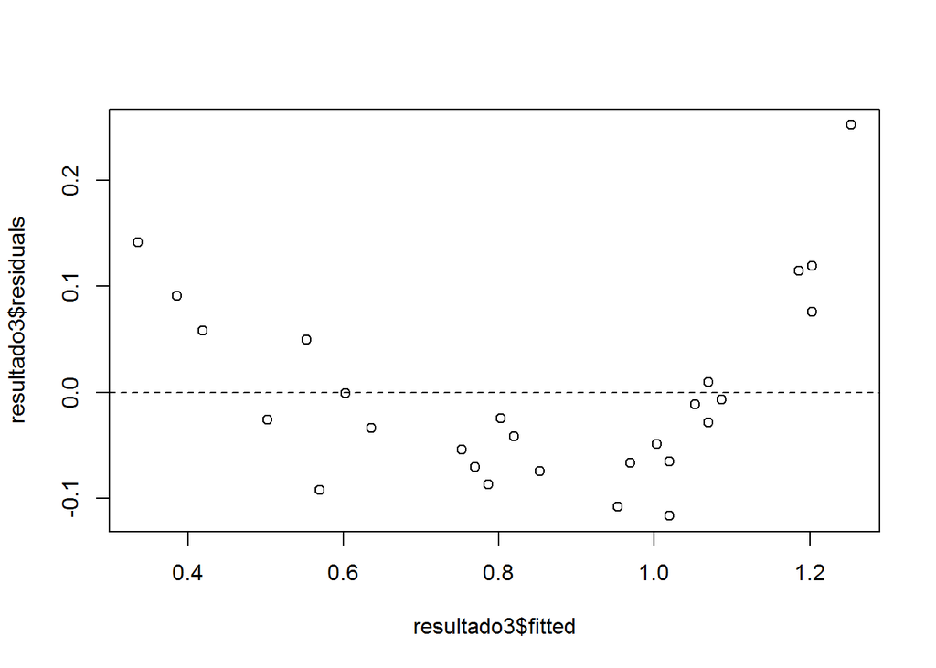

```r
plot(resultado3$fitted, resultado3$residuals,
abline(h=0,lty=2))
```

Eca, continua ruim, apesar de podermos ver uma ligeira (beeem ligeira) melhora.

#### Tentativa 3: quebrando a regressão.

Olhando os dados, podemos imaginar, com alguma facilidade, que existem dois padrões: um para as latitudes mais ou menos de 20 para baixo, e outro para as latitudes mais ou menos de 30 para cima.

Será que existe uma espécie de “quebra” no efeito da latitude sobre a riqueza de espécies?

Estamos dando um chute bem grande, mas vamos tentar só pelo aprendizado:

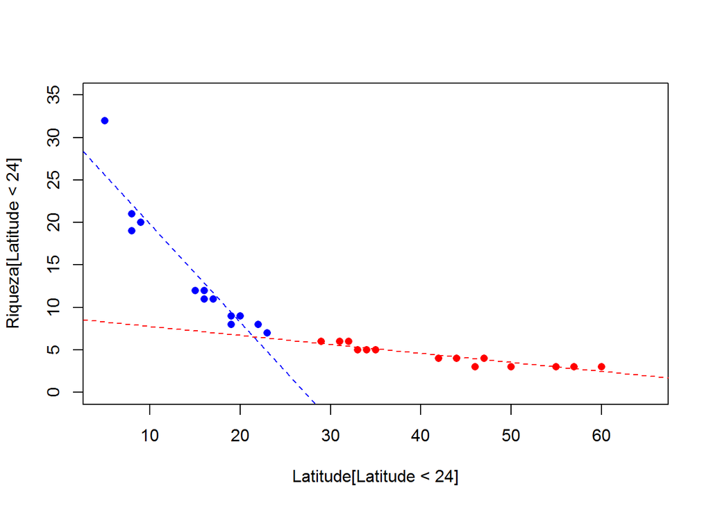

```r
resultado4.1<-lm(Riqueza[Latitude<24]~Latitude[Latitude<24])
resultado4.2<-lm(Riqueza[Latitude>28]~Latitude[Latitude>28])

plot(Riqueza[Latitude<24]~Latitude[Latitude<24], col="blue",
xlim=c(5, 65), ylim=c(0, 35), pch=16)

points(Riqueza[Latitude>28]~Latitude[Latitude>28],
pch=16, col="red")

abline(resultado4.1, lty=2, col="blue")
abline(resultado4.2, lty=2, col="red")
```

Que ficou bontinho, ficou. Mas será que os resíduos prestam? Desta vez são dois modelos, ok?

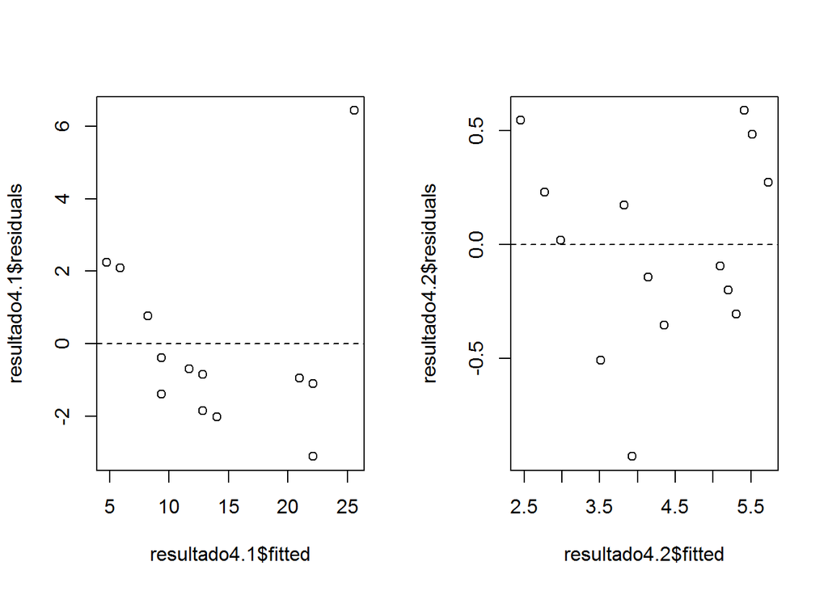

```r
par(mfrow=c(1,2))

plot(resultado4.1$fitted, resultado4.1$residuals,
abline(h=0,lty=2))

plot(resultado4.2$fitted, resultado4.2$residuals,
abline(h=0,lty=2))
```

Os resíduos do segundo modelo até que não ficaram horríveis, mas no primeiro a coisa continua feia…

#### Tentativa rápida e tosquinha de ajustar um modelo não linear

Lá vai:

```r
resultado.nl<-lm(Riqueza~Latitude+I(Latitude^2))

summary(resultado.nl)
```

```
##
## Call:
## lm(formula = Riqueza ~ Latitude + I(Latitude^2))
##
## Residuals:
##     Min      1Q  Median      3Q     Max
## -3.0810 -1.4694 -0.5276  1.4247  8.2887
##
## Coefficients:
##               Estimate Std. Error t value Pr(>|t|)
## (Intercept)   29.53749    1.69632  17.413 7.49e-16 ***
## Latitude      -1.23448    0.12116 -10.189 1.43e-10 ***
## I(Latitude^2)  0.01385    0.00181   7.652 4.03e-08 ***
## ---
## Signif. codes:  0 '***' 0.001 '**' 0.01 '*' 0.05 '.' 0.1 ' ' 1
##
## Residual standard error: 2.313 on 26 degrees of freedom
## Multiple R-squared:  0.8921, Adjusted R-squared:  0.8838
## F-statistic: 107.4 on 2 and 26 DF,  p-value: 2.702e-13
```

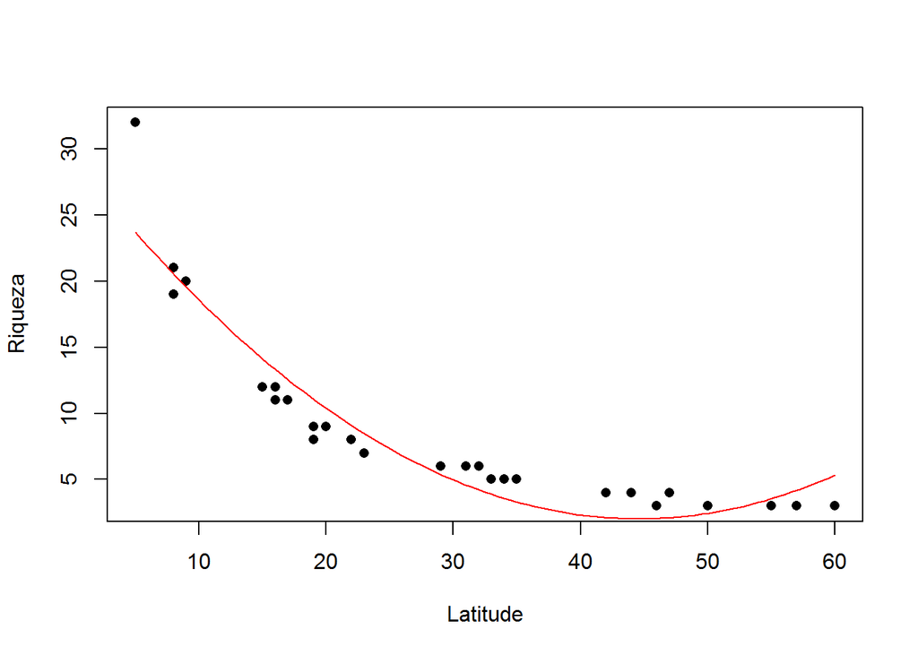

```r
plot(Riqueza~Latitude, pch=16)
curve(29.53749-1.23448*x+0.01385*x^2, add=T, col="red")
```

**E terminaos mais um. Nos vemos no próximo!**